# Week 10: Flexible Regression

PS 818 - Statistical Models

Anton Strezhnev

strezhnev@wisc.edu

University of Wisconsin-Madison

November 3, 2025

$$\require{cancel}
\DeclareMathOperator*{\argmin}{arg\,min}$$

$$\DeclareMathOperator*{\argmax}{arg\,max}$$

# Previously

- **Finite mixture models**
  - Model observed data as a **mixture** of discrete latent **categories**
  - Inference via **EM**
- **Item response theory**
  - **Factor model** for categorical/nominal outcome variables
  - Model a matrix of **individual** responses across multiple common **questions**
  - Responses are a function of a common **indivdual** latent parameter
  - Identification via Bayes (prior on the individual latent parameters defines the scale/location).

# This week

- **Flexible functional forms**
  - Semi-/Non-parametric approaches to modeling CEFs of $Y_i$ given a continuous $X_i$
  - Regression and smoothing splines to allow for flexible relationships between
  - Penalty term to avoid “jumpy” regressions
  - Generalized Additive Models (GAMs) that combine “parametric” and “semi-/non-parametric” components
- **Regularization**
  - Why regularize?
  - $L_0$, $L_1$, and $L_2$ norms
  - Value of the lasso (the $L_1$ norm) - “sparse” regressions
  - Interpreting regularization in Bayesian terms.

# Going Forward

- **Week 11** - Flexible Regression: Kernels and Forests
- **Week 12** - Flexible Regression: Gaussian Processes
- **Week 13** (No Class Wednesday) - Open Topic!
- **Week 14** - Semiparametric Inference
- **Week 15** - Big, Fast Regressions
- **Assignments**
  - Problem Set 4 - Assigned November 11th, Due December 1st
  - Final Exam - Assigned December 8th, Due December 15th

# Flexible regression

- A common task in statistics is estimating the conditional expectation function $E[Y|X]$.
  - But typical methods for estimating the CEF assume that we know its functional form.
  - For example, we assume linearity can be trivially satisfied when $X$ is discrete, but potentially problematic when $X$ is continuous.

  $$E[Y|X] = f(X) = X\beta$$
- We want to maintain the utility of a model that is **linear in the parameters** but introduce transformations of $X$ to capture potentially non-linear relationships between $Y$ and $X$.
- Define the **linear basis expansion** for a set of $M$ basis functions $h_m(X)$

  $$f(X) = \sum_{m=1}^M \beta_m h_m(X)$$

# Example: Modeling Bike Rentals

- **Bikeshare usage** is highly variable from day-to-day and hour-to-hour. Capital Bikeshare in Washington D.C. recorded the hourly count of active users over a two-year period from 2011 to 2012.
  - For more on the dataset, see: Fanaee-T, Hadi, and Gama, Joao, “Event labeling combining ensemble detectors and background knowledge”, *Progress in Artificial Intelligence* (2013): pp. 1-15

```r
bike <- read_csv("data/bikes_hour.csv")
bike_by_hour <- bike %>% group_by(hr) %>% summarize(cnt = mean(cnt))
```

# Example: Modeling Bike Rentals

- From the scatterplot of active usage vs. hour of the day, a simple linear fit (slope + intercept) seems quite poor at capturing the CEF

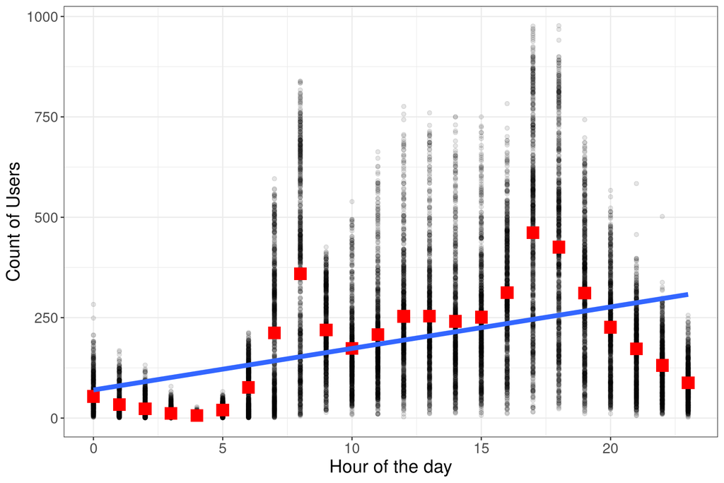

# Polynomial basis

- A common set of basis functions to choose are the **global polynomial** basis
  - You’ve probably already done this when you’ve included squared terms in your regressions!
- For example, for a univariate $X$, the basis for a global cubic polynomial is:

$$\begin{align*}h_1(X) &= 1\\
h_2(X) &= X\\
h_3(X) &= X^2\\
h_4(X) &= X^3\end{align*}$$

- A $K$th order polynomial requires $K+1$ parameters
- However, there are some drawbacks to using a global polynomial - namely that each observation influences the **entire** curve.

# Polynomial basis

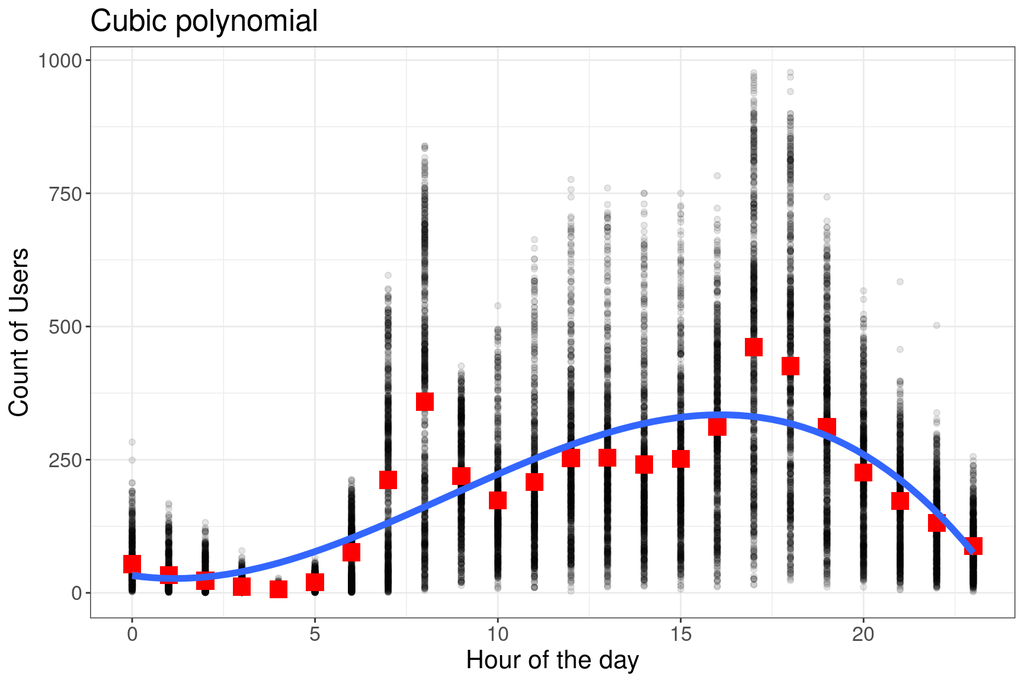

# Polynomial basis

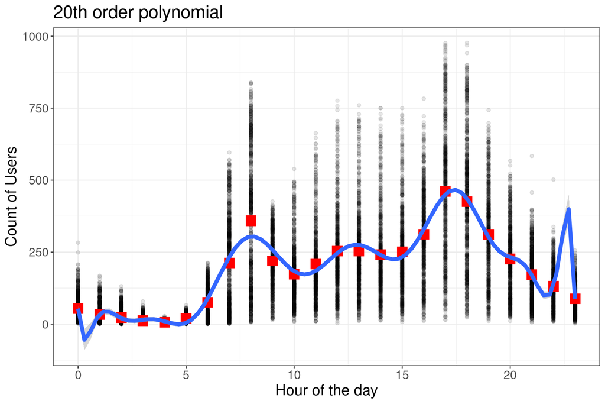

# Step functions

- Instead of forcing a single **global** polynomial, we might instead want to fit a set of **local** averages to different regions of $X$
- We could define a set of basis functions that are indicators which partition $X$ into $M+1$ disjoint regions based on cutpoints $\xi_1, \xi_2, \dotsc, \xi_{M}$

$$\begin{align*}
h_1(X) &= I(X < \xi_1)\\
h_2(X) &= I(\xi_1 \le X < \xi_2)\\
h_3(X) &= I(\xi_2 \le X < \xi_3)\\
&\vdots\\
h_{M+1}(X) &= I(\xi_{M} \le X)\\
\end{align*}$$

# Step functions

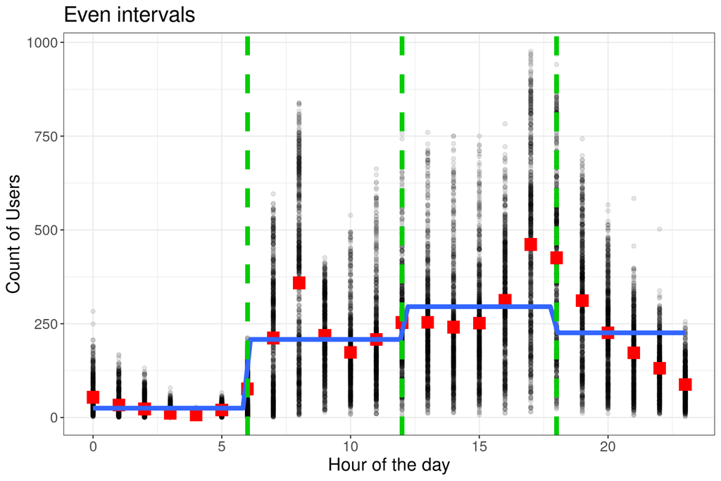

# Step functions

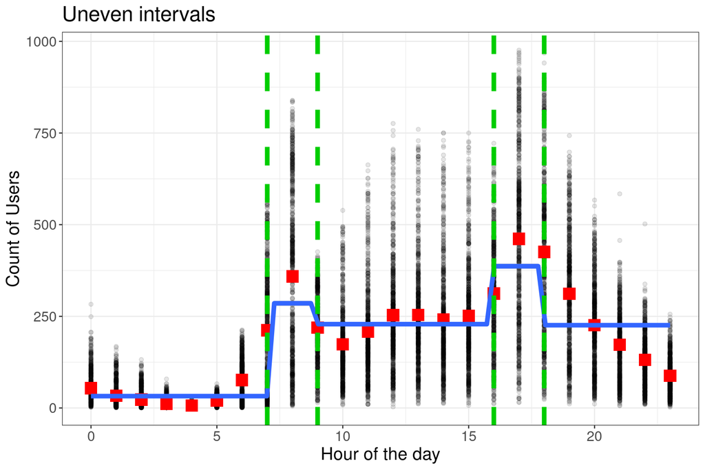

# Piecewise polynomials

- Rather than just taking the mean within each disjoint region, we could imagine fitting a polynomial to **just** that subset.

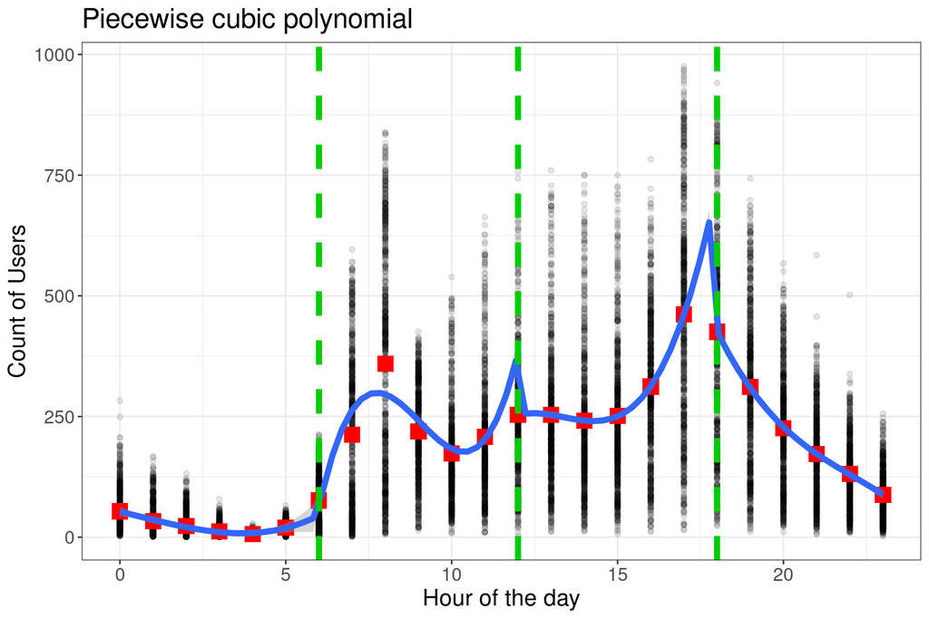

# Splines

- The piecewise polynomials might fit better, but we still have these irritating discontinuities in the CEF.
  - We might want to impose some **additional** conditions on the function regarding continuity around the cutpoints.
- A $K-1$th order **spline** with $M$ knots $\xi_1, \xi_2, \dotsc, \xi_{M}$ is a piece-wise polynomial that…
  - …is a polynomial of degree $K-1$ on the intervals $(-\infty, \xi_1,], [\xi_1, \xi_2], [\xi_2, \xi_3], \dotsc, [\xi_m, \infty)$
  - …has a $j$th derivative that is continuous at each of the knots $\xi_1, \xi_2, \dotsc, \xi_{m}$ for $j = 0, 1, 2, \dotsc, K-2$
- Intuitively, if we **also** forced the $k$th derivative to be continuous, we’d recover the **global** polynomial.
- Most common spline is the **cubic** spline $k = 4$ (third order polynomial).
  - Splines allow for local flexibility while still retaining continuity across $X$.

# Splines

- There are actually multiple ways to define the basis functions for a spline. The most intuitive for understanding how they work is the **truncated power basis**

$$\begin{align*}
h_{k}(X) &= x^{k-1} & \ \ & k = 1, \dotsc, K\\
h_{m+K}(X) &= (x - \xi_{m})_+^{K-1} & \ \ & m = 1, \dotsc, M
\end{align*}$$

where $(\cdot)_+$ denotes a function which returns $\text{max}(\cdot, 0)$

- Splines have $M + K$ “degrees of freedom”
  - “Natural” splines add the constraint that the function is **linear** beyond the constraints of the data
- When the degree and number of knots are fixed, commonly called **regression splines**
  - Contrast with **smoothing splines** where number of indirectly controlled via penalization
- **Trade-offs**
  - Higher $K$ and higher $M$ = better in-sample fit but risks overfitting
  - Lower $K$ and lower $M$ = poorer in-sample fit (baseline is a global polynomial), but potentially more robust out-of-sample.

# Splines

```r
bike %>% ggplot(aes(x=hr, y=cnt)) + geom_point(alpha=.1) + geom_point(data=bike_by_hour, col="red", shape=15, size=5)  +   geom_smooth(method="lm",  formula = y ~ x + I(x^2) + I(x^3) + I((x-6)>0):I((x - 6)^3) +  I((x-12)>0):I((x - 12)^3) + I((x-18)>0):I((x - 18)^3) , linewidth=2) +
  xlab("Hour of the day") + ylab("Count of Users") + ggtitle("Cubic spline with 6 degrees of freedom (+ intercept)") + geom_vline(xintercept = c(6, 12, 18), lty=2, linewidth=2, col="green3") +
  theme_bw() + theme(text = element_text(size = 16))
```

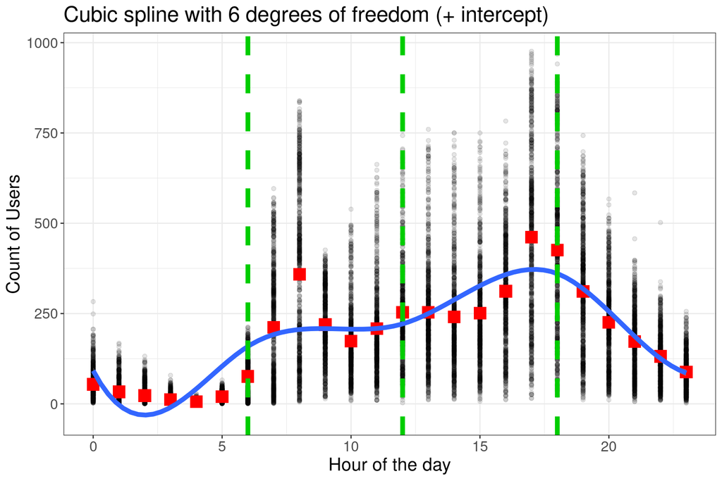

# B-splines

- Recall that there are multiple ways of defining the basis functions that construct a spline.
  - Truncated power basis is interpretable but can have poor computational properties
- Alternative: **B-spline** basis
  - Define the spline basis **recursively**
  - Advantage: Non-zero over a limited domain
- For a sequence of $K+M$ knots $\tau_1, \tau_2, \dotsc, \tau_{M+K}$

$$\begin{align*}
B_{i, 1}(x) &= \begin{cases} 1 & \text{if} &\tau_i \le x < \tau_{i+1}\\
0 & \text{otherwise} \end{cases}\\
B_{i, m}(x) &= \frac{x - \tau_i}{\tau_{i + m -1} -\tau_i} B_{i,m-1}(x) + \frac{\tau_{i+m} - x}{\tau_{i + m} - \tau_{i+1}} B_{i+1, m-1}(x)
\end{align*}$$

- **Intuition**: Basis functions for higher-order splines are weighted averages of the “neighboring” lower-order basis functions

# B-splines

- R will generate a b-spline basis for you using the `bs()` function in `splines`
  - You can treat these like transformations of the regressors

```r
bike_bs <- bs(bike$hr, df=6) # By default it's a cubic (degree = 3) and the intercept is omitted
head(bike_bs)
```

```
         1      2        3 4 5 6
[1,] 0.000 0.0000 0.000000 0 0 0
[2,] 0.383 0.0374 0.000772 0 0 0
[3,] 0.565 0.1327 0.006173 0 0 0
[4,] 0.594 0.2604 0.020833 0 0 0
[5,] 0.519 0.3951 0.049383 0 0 0
[6,] 0.388 0.5112 0.096451 0 0 0
```

```r
attributes(bike_bs)$knots
```

```
[1]  6 12 18
```

# Splines

```r
bike %>% ggplot(aes(x=hr, y=cnt)) + geom_point(alpha=.1) + geom_point(data=bike_by_hour, col="red", shape=15, size=5)  +   geom_smooth(method="lm",  formula = y ~ bs(x, df=6), linewidth=2) +
  xlab("Hour of the day") + ylab("Count of Users") + ggtitle("Cubic spline with 6 degrees of freedom (+ intercept)") + geom_vline(xintercept = c(6, 12, 18), lty=2, linewidth=2, col="green3") +
  theme_bw() + theme(text = element_text(size = 16))
```

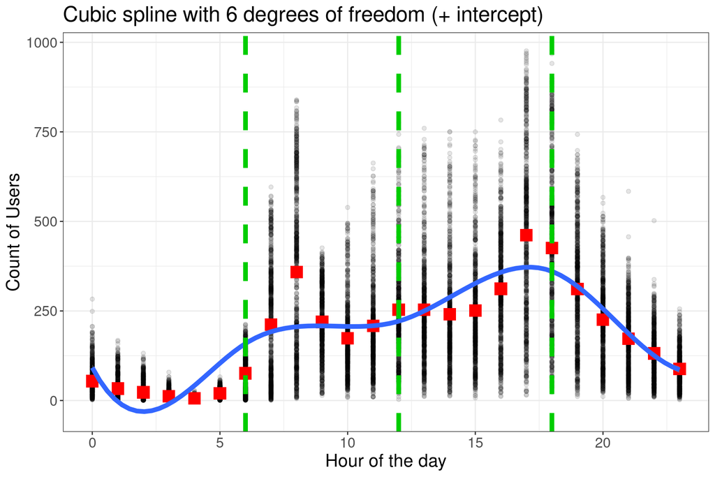

# Splines

```r
bike %>% ggplot(aes(x=hr, y=cnt)) + geom_point(alpha=.1) + geom_point(data=bike_by_hour, col="red", shape=15, size=5)  +   geom_smooth(method="lm",  formula = y ~ bs(x, df=6)[,1], linewidth=2) +
  xlab("Hour of the day") + ylab("Count of Users") + ggtitle("First cubic b-spline basis") + geom_vline(xintercept = c(6, 12, 18), lty=2, linewidth=2, col="green3") +
  theme_bw() + theme(text = element_text(size = 16))
```

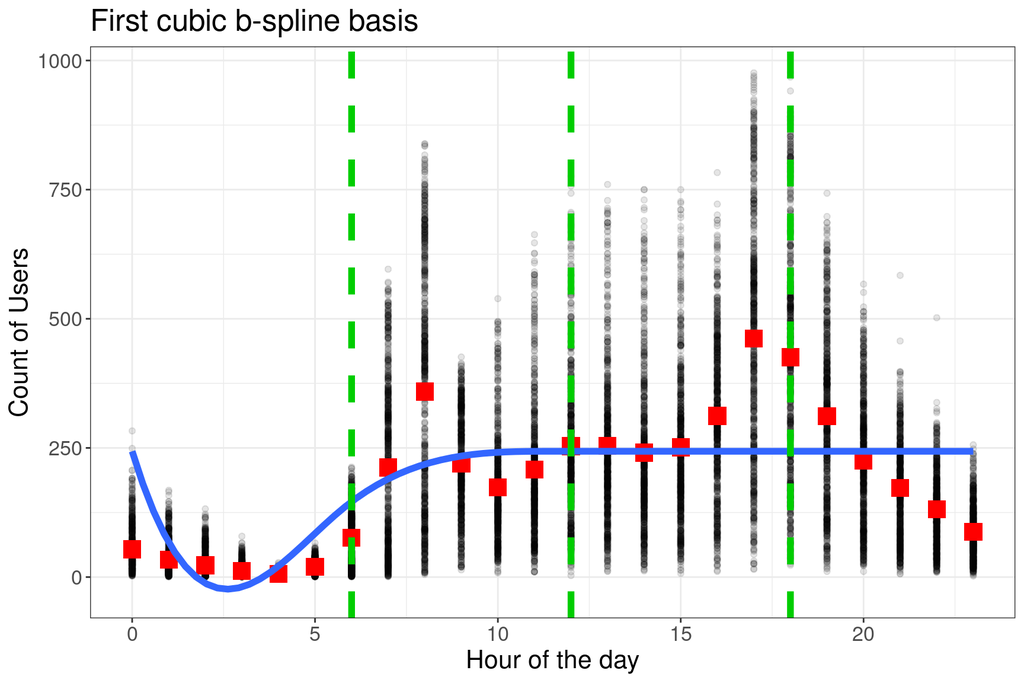

# Splines

```r
bike %>% ggplot(aes(x=hr, y=cnt)) + geom_point(alpha=.1) + geom_point(data=bike_by_hour, col="red", shape=15, size=5)  +   geom_smooth(method="lm",  formula = y ~ bs(x, df=6)[,4], linewidth=2) +
  xlab("Hour of the day") + ylab("Count of Users") + ggtitle("Fourth cubic b-spline basis") + geom_vline(xintercept = c(6, 12, 18), lty=2, linewidth=2, col="green3") +
  theme_bw() + theme(text = element_text(size = 16))
```

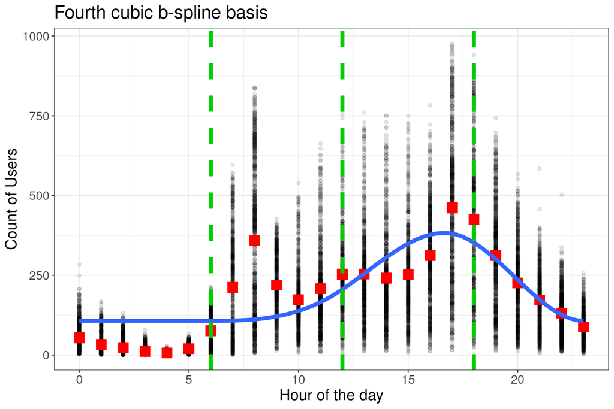

# Splines

- Splines with many degrees of freedom have potentially weird behavior in areas with little data - “squiggly” interpolations

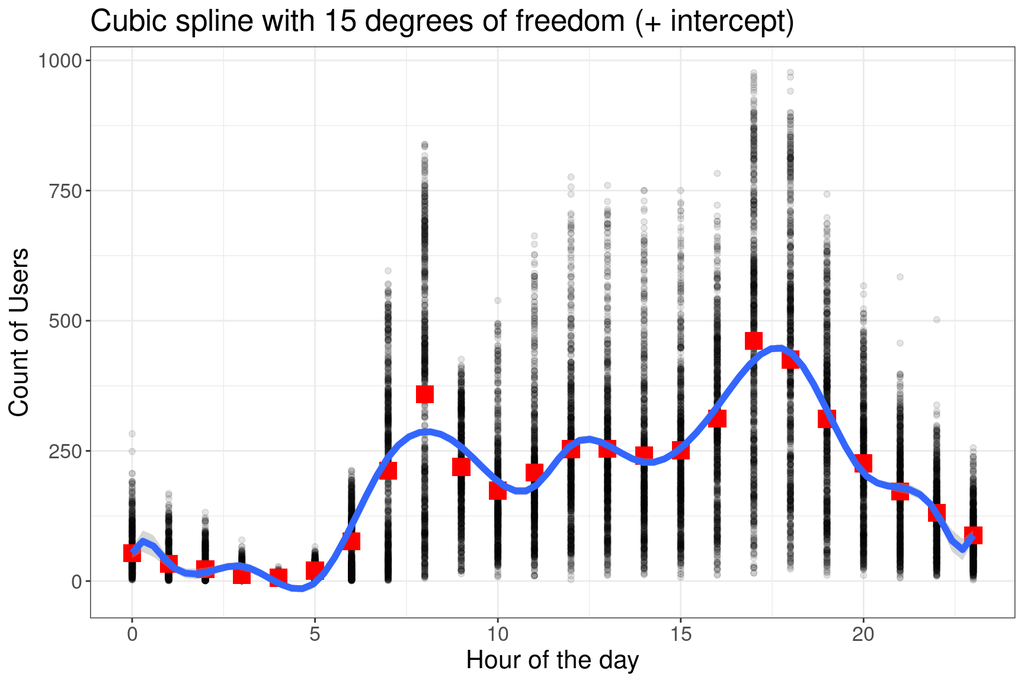

# Smoothing splines

- What if we set the **maximum** possible number of knots
  - $N$ total knots one for each observation
- Without penalization, we would have $N+4$ parameters for a cubic spline for $N$ observations.
  - This is not feasible using conventional least-squares - the solution is underdetermined!
- What if we controlled the fit via some **penalty** parameter
  - All-else-equal, we’d prefer a fit where the regression function is not very “jumpy”
  - Formalize this in terms of the second-derivative $f^{\prime\prime}(x)$
- Our “smoothing spline” takes the form of a **penalized** optimization problem. We want to find the function $f()$ that minimizes:

$$\sum_{i=1}^n (Y_i - f(X_i))^2 + \lambda \int \bigg(f^{\prime\prime}(x)\bigg)^2dx$$

where $\lambda$ is a non-negative “tuning” or “penalty” parameter.

# Smoothing splines

- It turns out that the function $f()$ that optimizes the “smoothing spline” objective function has some useful features
  1. It’s a piecewise cubic polynomial
  2. It has knots at the unique values of the data $x_1, x_2, \dotsc, x_N$
  3. It has continuous first and second derivatives at each of the knots.
  4. It’s linear outside of the knots
- It’s a **natural cubic spline**
  - But with **penalized** parameter estimates (shrunken towards zero)
- $\lambda$ chosen via cross-validation
  - Can conduct leave-one-out cross-validation very easily (formula exists to use the fit for all observations, so no need to re-fit)

# Generalized Additive Models

- **Generalized Additive Models** (GAMs) allow us to extend the conventional multiple linear regression model to accomodate the non-linear transformations of $X_i$.
- Instead of our original linear model:

$$Y_i = \beta_0 + \beta_1 X_{i1} + \beta_2 X_{i2} + \dotsc + \epsilon_{i}$$

- We fit:

$$Y_i = \beta_0 + f_1(X_{i1}) + f_2(X_{i2}) + \dotsc + \epsilon_{i}$$

- With conventional regression splines for $f_1(), f_2(), f_3()$, etc…, this just becomes a giant linear regression with the spline bases substituted for the original regressors
- With *smoothing splines*, slightly more complicated - can’t use OLS, but conventional software (`gam()` in R) implements the “backfitting” algorithm.
- Can extend to other functions $f_i()$ such as local regressions or just plain polynomials

# Generalized Additive Models

- Fitting our smoothing spline using the `gam()` function in the `mgcv` library

```r
hour_fit <- gam(cnt ~ s(hr, bs="cr"), data = bike)
summary(hour_fit)
```

```
Family: gaussian
Link function: identity

Formula:
cnt ~ s(hr, bs = "cr")

Parametric coefficients:
            Estimate Std. Error t value Pr(>|t|)
(Intercept)  189.463      0.992     191   <2e-16 ***
---
Signif. codes:  0 '***' 0.001 '**' 0.01 '*' 0.05 '.' 0.1 ' ' 1

Approximate significance of smooth terms:
      edf Ref.df    F p-value
s(hr)   9      9 1785  <2e-16 ***
---
Signif. codes:  0 '***' 0.001 '**' 0.01 '*' 0.05 '.' 0.1 ' ' 1

R-sq.(adj) =   0.48   Deviance explained =   48%
GCV =  17111  Scale est. = 17101     n = 17379
```

# Generalized Additive Models

- We can combine “parametric” and “non-parametric” terms in the `gam()` function

```r
hour_work_fit <- gam(cnt ~ workingday + s(hr, bs="cr"), data=bike)
summary(hour_work_fit)
```

```
Family: gaussian
Link function: identity

Formula:
cnt ~ workingday + s(hr, bs = "cr")

Parametric coefficients:
            Estimate Std. Error t value Pr(>|t|)
(Intercept)   181.73       1.76  103.27  < 2e-16 ***
workingday     11.33       2.13    5.32  1.1e-07 ***
---
Signif. codes:  0 '***' 0.001 '**' 0.01 '*' 0.05 '.' 0.1 ' ' 1

Approximate significance of smooth terms:
      edf Ref.df    F p-value
s(hr)   9      9 1787  <2e-16 ***
---
Signif. codes:  0 '***' 0.001 '**' 0.01 '*' 0.05 '.' 0.1 ' ' 1

R-sq.(adj) =  0.481   Deviance explained = 48.1%
GCV =  17085  Scale est. = 17074     n = 17379
```

# Generalized Additive Models

- Smoothing splines are also the default in `geom_smooth()` for large datasets

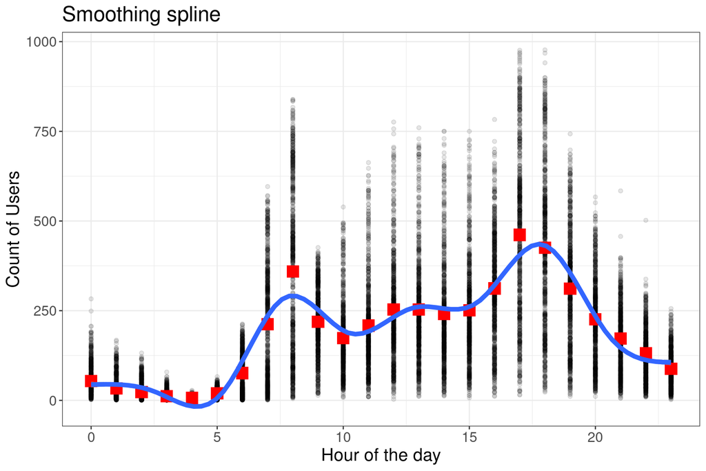

# Regularization

# Regularization

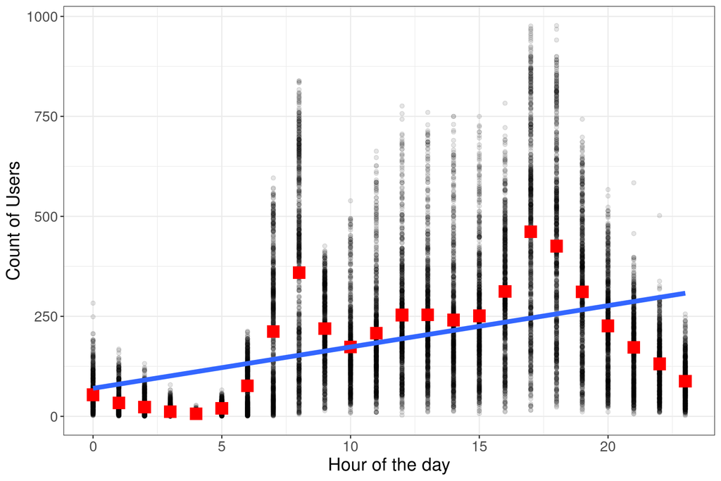

# Regularization

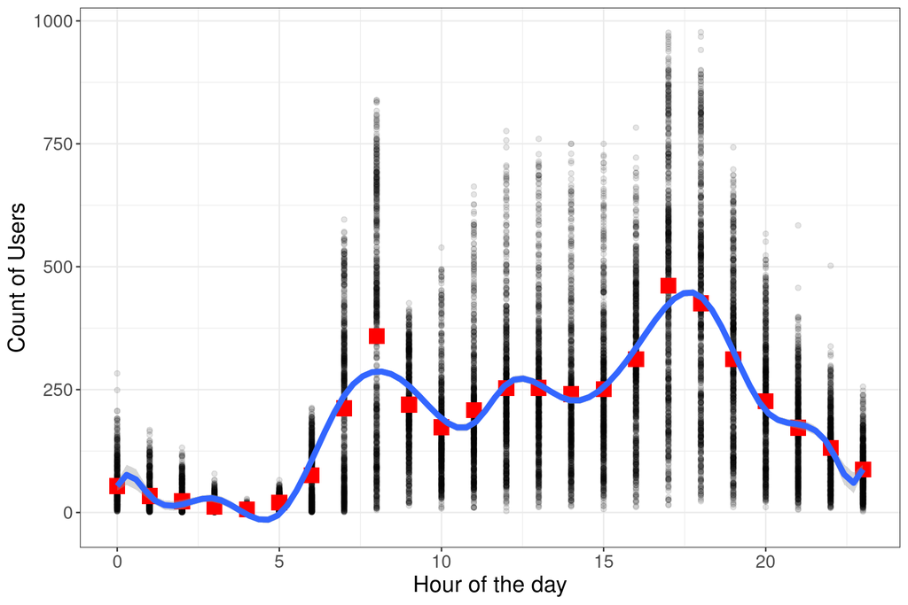

# Regularization

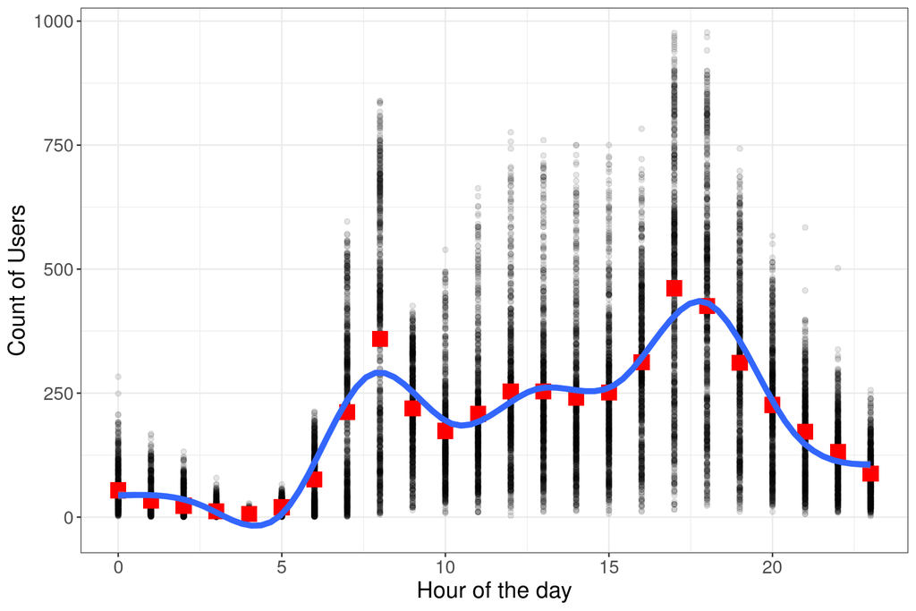

# Regularization

- The **error** of an estimator is a function of both its **bias** and its **variance**
  - We often talk about **unbiased** estimation as a goal of statistics?
  - Why? - Because we can accurately characterize the remaining error - the variance.
- But in other settings, we just want to know whether our point estimate is close to the truth
  - In this setting we might be willing to accept some **bias** in exchange for a reduction in variance.
- We’ve already done this to some extent:
  - Setting an **informative prior** in the Bayesian regression setting pulls the estimates to our existing beliefs
  - Sharper prior $\leadsto$ lower variance posterior distributions
- What sort of bias do we want to induce?
  - In a **regression**: bias the coefficients towards *zero*
  - Intuition: *betting on sparsity* - most regressors are irrelevant and their coefficients should be pulled towards zero.

# Mean Squared Error

- Recall that the **mean squared error** of an estimator $\hat{\theta}$ of some parameter $\theta$ can be decomposed into the (squared) **bias** and the **variance**

$$E\bigg[(\hat{\theta} - \theta)^2\bigg] = E\bigg[\theta^2\bigg] - 2\theta E\bigg[\hat{\theta}\bigg] + \theta^2$$

- Add and subtract $E[\hat{\theta}]^2$

$$E\bigg[(\hat{\theta} - \theta)^2\bigg] = \bigg(E[\theta^2]- E[\hat{\theta}]^2\bigg) + E[\hat{\theta}]^2 - 2\theta E[\hat{\theta}] + \theta^2$$

- And factoring to get the bias squared

$$\underbrace{E\bigg[(\hat{\theta} - \theta)^2\bigg]}_{\text{MSE}} = \underbrace{\bigg(E[\theta^2]- E[\hat{\theta}]^2\bigg)}_{\text{Variance}} + \underbrace{\bigg(E[\hat{\theta} - \theta]\bigg)^2}_{\text{Squared Bias}}$$

# Notation notes

- We’re going to work with a standard regression setting with outcome $Y_i$ and covariate matrix $\mathbf{X}$.
  - We’ll assume the covariates are **standardized** to have mean zero and variance 1 (we don’t want our regularizer to depend on the scale of the inputs).
- Let $||\cdot||_p$ denote the $L_p$ norm.
  - The $L_2$ norm is the **euclidean norm**: $|| \beta ||_2 = \sqrt{\sum_{k=1}^K |\beta|^2}$
  - The $L_1$ norm is the sum of the absolute values $|| \beta ||_1 = \sum_{k=1}^K |\beta|$
  - More generally, the $L_p$ norm is: $|| \beta ||_p = \bigg(\sum_{k=1}^K |\beta|^p\bigg)^{\frac{1}{p}}$

# Example: Predicting Peace Agreements

- Many predictive involve **large numbers of covariates** relative to the total number of observations
  - If all of the covariates are in some sense “relevant” then you’re probably out of luck.
  - But in most settings, only a handful of the covariates actually matter…the problem is that you don’t know which ones ex-ante.
- The **UCDP Peace Agremeents dataset** contains information on peace agreements to armed conflicts from the period 1975-2021
  - We may want to know what factors predict durable peace agreements.

```r
pa <- read_csv("data/ucdp-peace-agreements-221.csv")
```

- Some brief pre-processing of the outcome

```r
# If agreement remains, then duration = "now"
pa$duration_complete <- pa$duration
pa$duration[is.na(pa$duration)] <- ymd("2021-12-31")
pa$durationDays <- as.numeric(pa$duration - pa$pa_date)
# Fill in missing "ended' data
pa$ended_full <- as.numeric(pa$ended)
pa$ended_full[is.na(pa$ended_full)] <- 0
```

# Example: Predicting Peace Agreements

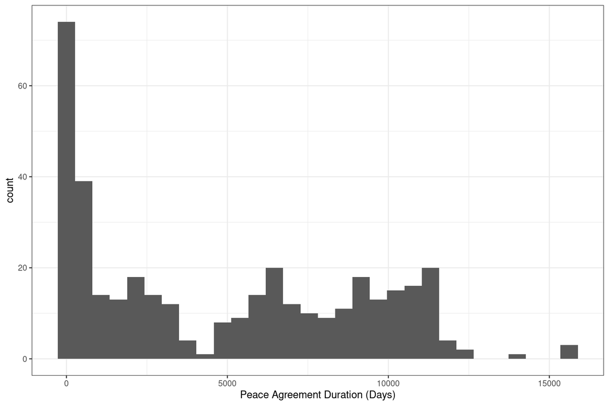

# Example: Predicting Peace Agreements

- Our covariates are a large number of coded features for each agreement

```r
pa_x <- model.matrix(durationDays ~ as.factor(region) + bs(year, df=8) + as.factor(incompatibility) +
                       cease + intarmy + ddr + withd + mil_prov + pp + intgov + intciv +
                       elections + interim + natalks + shagov + pol_prov + aut + fed + ind +
                       ref + shaloc + regdev + cul + demarcation + locgov + terr_prov + amn +
                       pris + recon + return + justice_prov + reaffirm + outlin + pko + gender +
                       co_impl + termdur + txt + as.factor(inclusive) + as.factor(pa_type) +
                       as.factor(out_iss) + as.factor(frame), data=pa)[,-1]
```

# Ridge regression

- Our typical (gaussian) linear regression estimator finds the $\beta$ that **minimizes** the residual sum of squares (RSS)

$$\text{RSS} = \sum_{i=1}^N (Y_i - X_i^{\prime}\beta)^2$$
- For non-gaussian models, replace the residual sum of squares with the log-likelihood (the RSS *is* the negative log-likelihood for a gaussian)

- **Ridge regression** augments the objective function by adding a penalty term

$$\sum_{i=1}^N (Y_i - X_i^{\prime}\beta)^2 + \lambda\sum_{k=1}^K \beta_k^2$$
where $\lambda$ is a user-specified penalty parameter

- Note that we’ll typically avoid regularizing the **intercept** $\beta_0$.

# Bayesian interpretation

- Ridge regression has an interpretation in terms of a **bayesian regression**
- Consider our normal model with:

$$Y_i |X_i, \beta \sim \text{Normal}(X_i^{\prime}\beta, \sigma^2)$$

- The log-posterior can be written as

$$\log p(\beta | \mathbf{X}, Y) \propto \log p(Y | \mathbf{X}, \beta) + \log p(\beta)$$

- In a gaussian model, the first part is just the (negative) residual sum of squares

$$\log p(\beta | \mathbf{X}, Y) \propto - \frac{1}{2\sigma^2}\sum_{i=1}^N (Y_i - X_i^{\prime}\beta)^2 + \log p(\beta)$$

# Bayesian interpretation

- Now, suppose we put a conventional normal prior on $\beta$

$$\beta \sim \text{Normal}(0, \tau^2I)$$

- $\log p(\beta)$ can then be written as:

$$\begin{align*}\log p(\beta) &= -\frac{1}{2\tau^2} \sum_{k=1}^K (\beta_k - 0)^2\\
&= -\frac{1}{2\tau^2} \sum_{k=1}^K \beta_k^2\end{align*}$$

- Plugging back in to the log-posterior, we have

$$\log p(\beta | \mathbf{X}, Y) \propto - \frac{1}{2\sigma^2}\sum_{i=1}^N (Y_i - X_i^{\prime}\beta)^2 - \frac{1}{2\tau^2} \sum_{k=1}^K \beta_k^2$$

# Bayesian interpretation

- Rearranging terms and dropping scaling constants, we have

$$\log p(\beta | \mathbf{X}, Y) \propto - \sum_{i=1}^N (Y_i - X_i^{\prime}\beta)^2 - \frac{\sigma^2}{\tau^2} \sum_{k=1}^K \beta_k^2$$

- With $\lambda = \frac{\sigma^2}{\tau^2}$, this is just the negative of the ridge regression objective function
  - Maximizing the log-posterior (finding the MAP estimate) is equivalent to minimizing a ridge regression objective!

# Visualizing the penalty

- Penalized regression can also be interpreted as a **constrained optimization problem**
- Find the $\beta$ that minimizes:

$$\text{RSS} = \sum_{i=1}^N (Y_i - X_i^{\prime}\beta)^2$$
- Subject to

$$\sum_{k=1}^K \beta_k^2 \le s$$

- We prefer the unconstrained formulation with $\lambda$ for computation, but the constrained view allows us to get a sense of how the ridge regularizer is operating.

# Visualizing the penalty

# Example: Predicting Peace Agreements

- The standard library for estimating penalized regressions in R is `glmnet`
  - By default, R will fit the model for a **regularization sequence** of $\lambda$
  - Actually choosing a $\lambda$ is done via cross-validation
- Let’s fit a gaussian model (we could do poisson as well, but gaussian is easy)

```r
# alpha=0 is the ridge penalty
conflict_ridge <- glmnet(x=pa_x, y=log(pa$durationDays), family="gaussian", alpha=0, standardize=T)
```

# Example: Predicting Peace Agreements

- How is the in-sample fit?

```r
plot(x=log(conflict_ridge$lambda), y=1-conflict_ridge$dev.ratio, type='l', xlab="(logged) Lambda", ylab="1 - Fraction of the deviance explained")
```

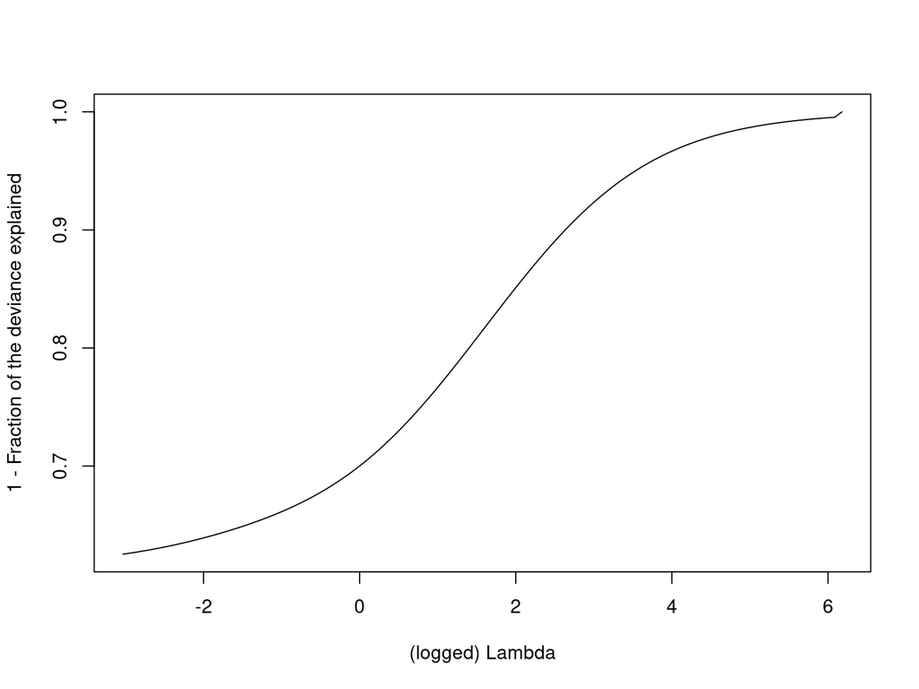

# Selecting the penalty

- $\lambda$ is typically selected via cross-validation

```r
conflict_ridge_cv <- cv.glmnet(x=pa_x, y=log(pa$durationDays), family="gaussian", alpha=0, standardize=T)
print(conflict_ridge_cv)
```

```
Call:  cv.glmnet(x = pa_x, y = log(pa$durationDays), family = "gaussian",      alpha = 0, standardize = T)

Measure: Mean-Squared Error

    Lambda Index Measure    SE Nonzero
min   1.51    63    3.21 0.360      61
1se  20.40    35    3.57 0.408      61
```

- `cv.glmnet` typically provides two choices of $\lambda$
  - The first being the value that minimizes the cross-validation error (`min`)
  - The second being the largest value of $\lambda$ that is still within 1 standard error from the minimum (`1se`)

# Selecting the penalty

- Low penalties can lead to **bad** out-of-sample fit!

```r
plot(x=log(conflict_ridge_cv$lambda), y=conflict_ridge_cv$cvm, type='l', xlab="(logged) Lambda", ylab="Cross-validation error")
```

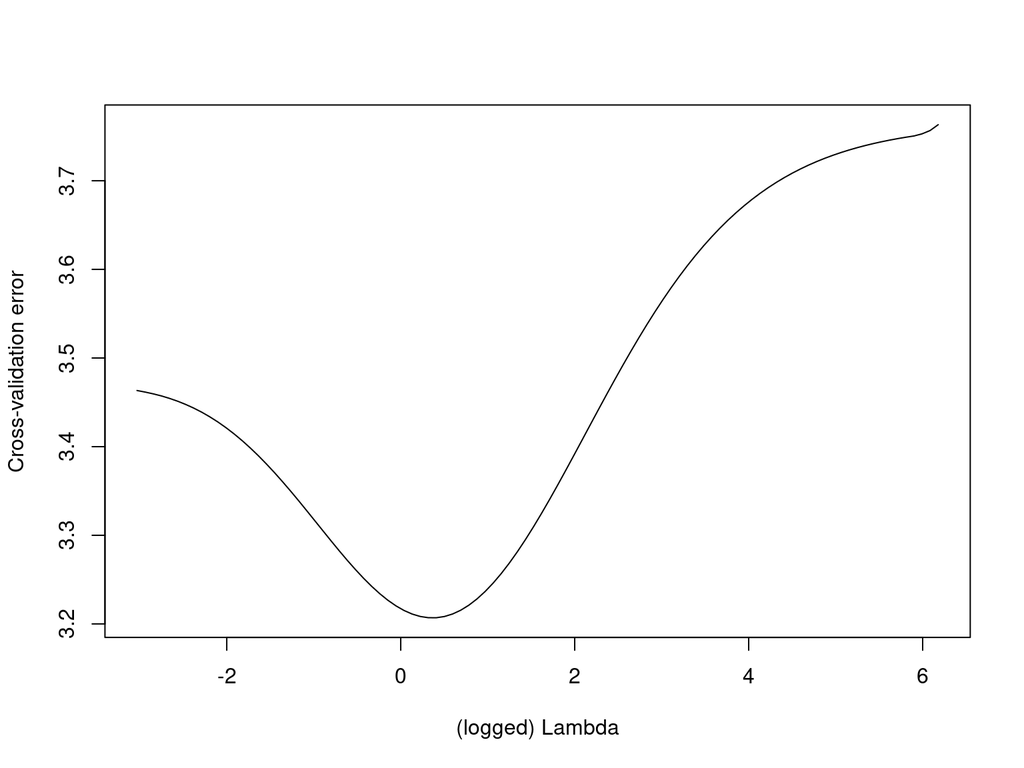

# Lasso

- **Ridge regression** regularizes the coefficients towards zero, but it does not guarantee that some coefficients are exactly zeroed out.
  - In other words, it does not do **model selection**
- We would like to have a penalty term that results in **sparse** solutions - ones where many coefficients are explicitly set to $0$
  - The $L_1$ penalty accomplishes this!
  - The **least absolute shrinkage and selection operator** or lasso is the same penalized regression as the ridge regression but with the sum of the **absolute** rather than squared coefficients in the penalty

$$\sum_{i=1}^N (Y_i - X_i^{\prime}\beta)^2 + \lambda\sum_{k=1}^K |\beta_k|$$

- The $L_1$ norm is non-differentiable with respect to the covariates at $0$, which leads to the lasso acting as a “selection” operator on the elements of $\beta$

# Visualizing the lasso

- As with ridge, the lasso has an expression in terms of a constrained optimization problem:
- Find the $\beta$ that minimizes:

$$\text{RSS} = \sum_{i=1}^N (Y_i - X_i^{\prime}\beta)^2$$
- Subject to

$$\sum_{k=1}^K |\beta_k| \le s$$

# Visualizing the lasso

# Bayesian lasso

- The lasso also has an interpretation as a Bayesian prior placed on $\beta$.
  - But instead of the normal, the prior is the **Laplace** or double-exponential distribution
  - Location parameter $\mu = 0$, scale parameter $b$

$$p(\beta_k) = \frac{1}{2b} \exp\bigg\{ -\frac{|\beta_k|}{b}\bigg\}$$

# Example: Predicting Peace Agreements

```r
# alpha=1 is the lasso penalty
conflict_lasso <- glmnet(x=pa_x, y=log(pa$durationDays), family="gaussian", alpha=1)
```

# Example: Predicting Peace Agreements

- We can count the number of coefficients set to $0$ as $\lambda$ increases

```r
plot(x=log(conflict_lasso$lambda), y=colSums(coef(conflict_lasso) == 0), type='l', xlab="(logged) Lambda", ylab="Number of zero coefficients")
```

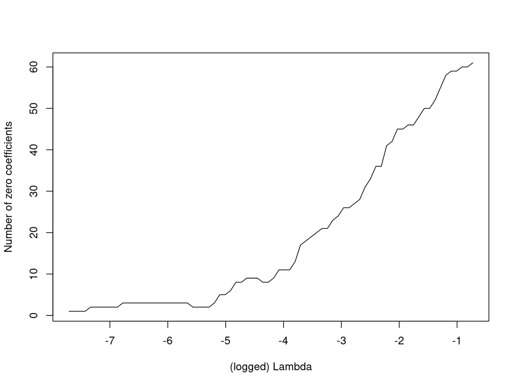

# Example: Predicting Peace Agreements

- In-sample fit improves as we reduce $\lambda$

```r
plot(x=log(conflict_lasso$lambda), y=1- conflict_lasso$dev.ratio, type='l', xlab="(logged) Lambda", ylab="1 - Fraction of the deviance explained")
```

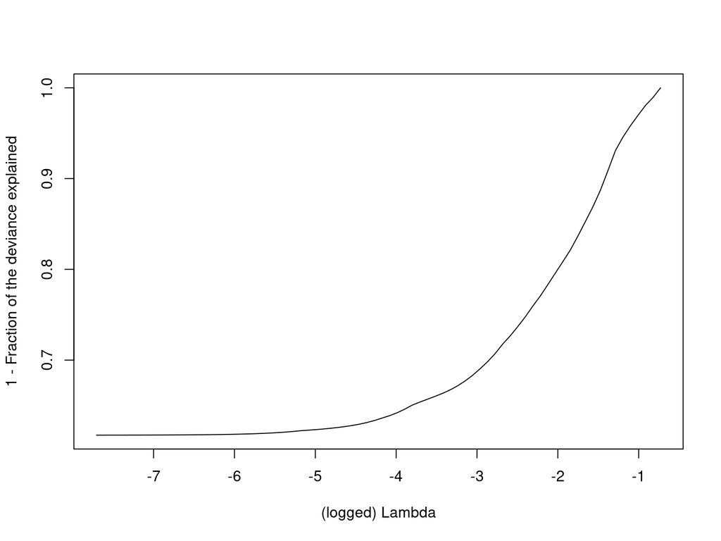

# Example: Predicting Peace Agreements

- We again choose $\lambda$ via cross-validation

```r
conflict_lasso_cv <- cv.glmnet(x=pa_x, y=pa$durationDays, family="gaussian", alpha=1)
print(conflict_lasso_cv)
```

```
Call:  cv.glmnet(x = pa_x, y = pa$durationDays, family = "gaussian",      alpha = 1)

Measure: Mean-Squared Error

    Lambda Index  Measure     SE Nonzero
min   39.5    40 13314788 514100      49
1se  279.0    19 13805985 594014      22
```

# Example: Predicting Peace Agreements

- Cross-validation error does not strictly improve with lower $\lambda$

```r
plot(x=log(conflict_lasso_cv$lambda), y=conflict_lasso_cv$cvm, type='l', xlab="(logged) Lambda", ylab="Cross-validation error")
```

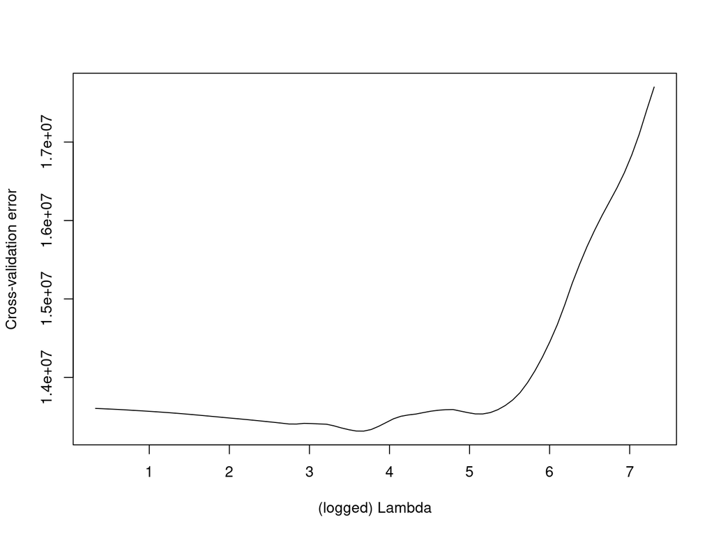

# Lasso as variable selection

- **Variable selection** is a common problem in statistics
  - We assume a world where among our covariates $X$, some small subset have actual non-zero coefficients (they “matter”) but most don’t.
  - The problem is that ex-ante, we have no idea what the relevant covariates actually are!
- Classical approaches
  - **Forward selection** - Start with an empty model and add variables one-by-one.
  - **Backward selection** - Start with a full model and remove the least correlated variables one-by-one.
- The lasso can be thought of as an alternative to these techniques
  - Advantages in computational time/feasibility as well as potential **predictive** benefits from shrinkage.

# Example: Predicting Peace Agreements

- Let’s fit the lasso with the “best” cross-validated $\lambda$

```r
conflict_lasso_best <- glmnet(x=pa_x, y=pa$durationDays, family="gaussian", alpha=1, lambda=conflict_lasso_cv$lambda.min)
```

- Which coefficients are non-zero?

```r
coef(conflict_lasso_best)[,1][coef(conflict_lasso_best)[,1] != 0]
```

```
                   (Intercept)             as.factor(region)2
                       5237.48                       -4500.30
            as.factor(region)3             as.factor(region)4
                      -1818.06                       -2580.34
            as.factor(region)5              bs(year, df = 8)1
                      -1199.10                        5200.78
             bs(year, df = 8)2              bs(year, df = 8)3
                       7516.60                        2553.39
             bs(year, df = 8)4              bs(year, df = 8)5
                       3950.44                        3048.67
             bs(year, df = 8)8 as.factor(incompatibility)1, 2
                       -880.34                         269.46
   as.factor(incompatibility)2 as.factor(incompatibility)2, 1
                       -342.67                        -797.89
   as.factor(incompatibility)3                          cease
                        848.20                        -928.03
                       intarmy                            ddr
                         34.09                         553.30
                            pp                         intciv
                        197.52                        1019.07
                     elections                        interim
                       -196.86                        -184.60
                       natalks                            aut
                      -1646.12                        -671.38
                           fed                            ind
                       -628.01                        2460.97
                           ref                         regdev
                       1625.63                       -1181.74
                   demarcation                         locgov
                        130.92                        -217.54
                     terr_prov                           pris
                        119.34                        -564.19
                         recon                         return
                       -164.51                         830.81
                      reaffirm                         outlin
                       1037.04                        1109.76
                           pko                         gender
                       -520.61                        -701.37
                       co_impl                        termdur
                        321.19                           9.01
                           txt          as.factor(inclusive)2
                        725.74                        -620.54
           as.factor(pa_type)2            as.factor(pa_type)3
                      -1610.84                       -2093.35
           as.factor(out_iss)1            as.factor(out_iss)2
                       1152.88                         476.21
           as.factor(out_iss)3            as.factor(out_iss)5
                       -236.77                       -1560.28
             as.factor(frame)2              as.factor(frame)3
                        186.35                        -538.81
```

# Example: Predicting Peace Agreements

- What if we took the “selected” variables and just ran OLS?

```r
pa_x_use <- cbind(1, pa_x[,names(coef(conflict_lasso_best)[,1][coef(conflict_lasso_best)[,1] != 0])[-1]])
beta_ols <- as.vector(solve(t(pa_x_use)%*%pa_x_use)%*%t(pa_x_use)%*%log(pa$durationDays))
names(beta_ols) <- names(coef(conflict_lasso_best)[,1][coef(conflict_lasso_best)[,1] != 0])
beta_ols
```

```
                   (Intercept)             as.factor(region)2
                        8.8452                        -2.2515
            as.factor(region)3             as.factor(region)4
                       -1.6154                        -1.8988
            as.factor(region)5              bs(year, df = 8)1
                       -1.1362                        -1.2264
             bs(year, df = 8)2              bs(year, df = 8)3
                        2.2729                        -0.1505
             bs(year, df = 8)4              bs(year, df = 8)5
                        1.1822                         1.6537
             bs(year, df = 8)8 as.factor(incompatibility)1, 2
                       -0.1102                         0.9273
   as.factor(incompatibility)2 as.factor(incompatibility)2, 1
                       -0.4536                        -0.7501
   as.factor(incompatibility)3                          cease
                       -0.0271                        -0.4286
                       intarmy                            ddr
                        0.1749                         0.1732
                            pp                         intciv
                        0.2007                         0.6205
                     elections                        interim
                        0.0990                         0.0481
                       natalks                            aut
                       -1.3177                        -0.4982
                           fed                            ind
                       -0.7574                         0.4624
                           ref                         regdev
                        0.5294                        -0.3691
                   demarcation                         locgov
                        0.5058                         0.1433
                     terr_prov                           pris
                        0.1210                        -0.4537
                         recon                         return
                       -0.0956                         0.5288
                      reaffirm                         outlin
                        0.6695                         0.4453
                           pko                         gender
                       -0.2413                        -0.3118
                       co_impl                        termdur
                        0.2048                         0.0113
                           txt          as.factor(inclusive)2
                        0.2721                        -0.1916
           as.factor(pa_type)2            as.factor(pa_type)3
                       -0.7338                        -0.6556
           as.factor(out_iss)1            as.factor(out_iss)2
                        0.7253                         0.3353
           as.factor(out_iss)3            as.factor(out_iss)5
                       -0.3909                        -0.7985
             as.factor(frame)2              as.factor(frame)3
                        0.1239                         0.0487
```

# Causal inference and “double lasso”

- Lasso coefficients are **biased** towards zero
  - This bias is often desirable for prediction (see Stein’s paradox)
  - But this bias is undesirable for inference (conventional CIs don’t have the right coverage).
- Often we have a causal inference problem where the goal is to estimate the effect of some treatment $D_i$ on outcome $Y_i$ under an assumption of **selection-on-observables** given $X_i$
  - But we don’t know which covariates matter (or possibly their functional forms).
  - We want to control for variables that predict $Y_i$ and predict $D_i$ - degree of omitted variable bias is a **product** of these two relationships

# Causal inference and “double lasso”

- **Belloni, Chernozhukov and Hansen (2014)** suggest an approach that uses the lasso for variable selection but OLS to obtain an unbiased estimator of the treatment effect - the “double lasso”
- **Step 1:** Fit a **lasso** regression of outcome on covariates

$$Y_i = \alpha_0 + \alpha_1 X_{i1} + \alpha_2 X_{i2} + \dotsc \alpha_K X_{iK} + \epsilon_i$$

- **Step 2:** Fit a **lasso** regression of treatment on covariates

$$D_i = \delta_0 + \delta_1 X_{i1} + \delta_2 X_{i2} + \dotsc \delta_K X_{iK} + \epsilon_i$$

- **Step 3:** Let $A$ denote the set of covariates selected in **either** the first or the second regression.
- **Step 4:** Fit an **OLS** regression of outcome on treatment and the covariates in $A$

$$Y_i = \tau D_i + \sum_{k \in A} \beta_k X_{ik} + \epsilon_i$$